# Wake efficiency correction

february 26, 2017

# Synopsis

In this study we investigate the impact of wind turbine type (rotor size, generator size and hub height) on the wake efficiency. The overall idea is to build a simple model that could be able to predict(/correct) the wake effect of a specific configuration (turbine type) based on another “reference” configuration. It should be noted that it is a “macro” approach that does not go into the details of the wake model equations. 4 turbine characteristics have been identified to potentially have an impact on the wake effect:

- hub height
- wind speed
- rotor size
- generator size

To build this model, 5 sites of 17 WTGs have been selected across the Northern Europe countries. On each site, multiple configurations have been computed using winPRO 3.1 with the standard wake model (N.O Jense, WDC = 0.075). To assess the impact of each parameters on wake efficiency, a reference configuration has been chosen (hub height + rotor + generator) and from this reference, each parameter has been tuned one by one (keeping the other constant).

All inputs and the script can be found on this link: https://github.com/Umercia/wake

# Input Data & Processing

Basic data processing has been done: It mainly consists of reading, subsetting and parsing data. Sample view of the input data after processing:

```
##      site label efficiency rotor generator hub_height wind_speed
##   1:    A    F1    91.0994   126      3450         80       7.81
##   2:    A    F2    92.7376   126      3450         80       7.78
##   3:    A    F3    88.7298   126      3450         80       7.91
##   4:    A    F4    89.0042   126      3450         80       7.74
##   5:    A    F5    88.2402   126      3450         80       8.01
##  ---
## 863:    E  Ka13    89.3397   136      3300         80       6.54
## 864:    E  Ka14    85.2713   136      3300         80       6.56
## 865:    E  Ka15    83.9460   136      3300         80       6.55
## 866:    E  Ka16    86.2859   136      3300         80       6.55
## 867:    E  Ka17    92.1700   136      3300         80       6.52
```

Summary of the parsed data:

```
##  site      efficiency    rotor     generator  hub_height   wind_speed
##  A:170   Min.   :73.79   105:187   3000:187   80 :289    Min.   : 6.390
##  B:187   1st Qu.:89.93   117:204   3300:306   100:187    1st Qu.: 7.220
##  C:170   Median :93.07   126:289   3450:187   120:204    Median : 7.770
##  D:170   Mean   :92.37   136:187   3600:187   140:187    Mean   : 7.823
##  E:170   3rd Qu.:96.07                                   3rd Qu.: 8.520
##          Max.   :99.48                                   Max.   :10.330
```

Rotor goes from 105m to 136m, generator size from 3MW to 3.6MW, and hub height from 80m to 140m.

# Plots and model variables

For each parameters, 4 graphics have been built, showing step by step how the model is build.

1. visualisation of the results
2. model construction
3. test of the model
4. comparison of the deviation with/without model

### Plot1: Wind speed

Plot 1.1 shows the variation of efficiency along wind speed. For each pad a fitted line is plotted.

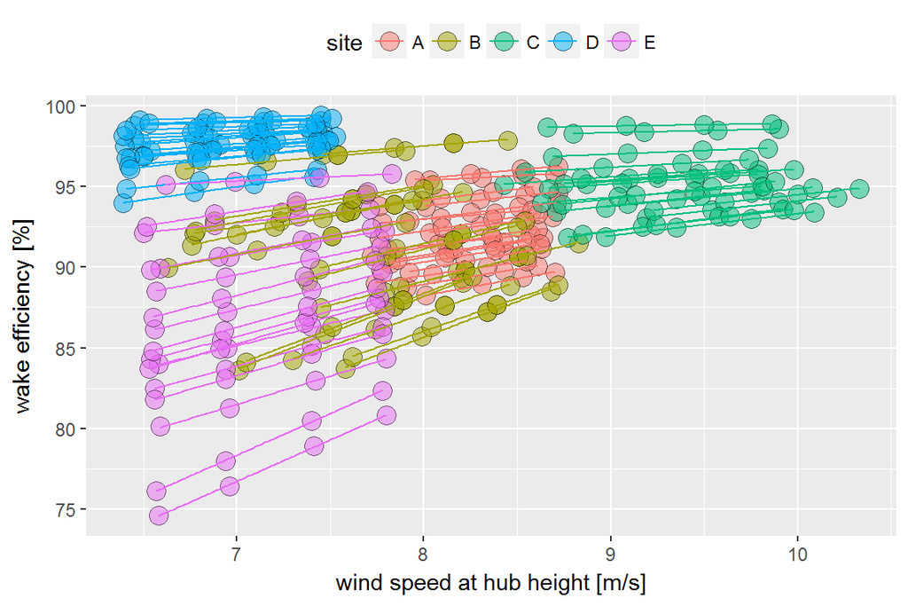

Plot 1.2 shows the variation of the fitted line slopes along efficiency. Again, we will fit a line that would be used for our model.

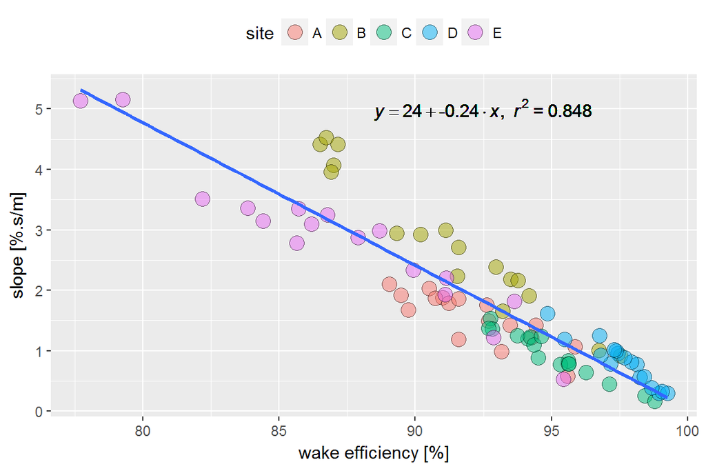

Plot 1.3 shows the results of the model (dashed lines) using a reference point for each pad.

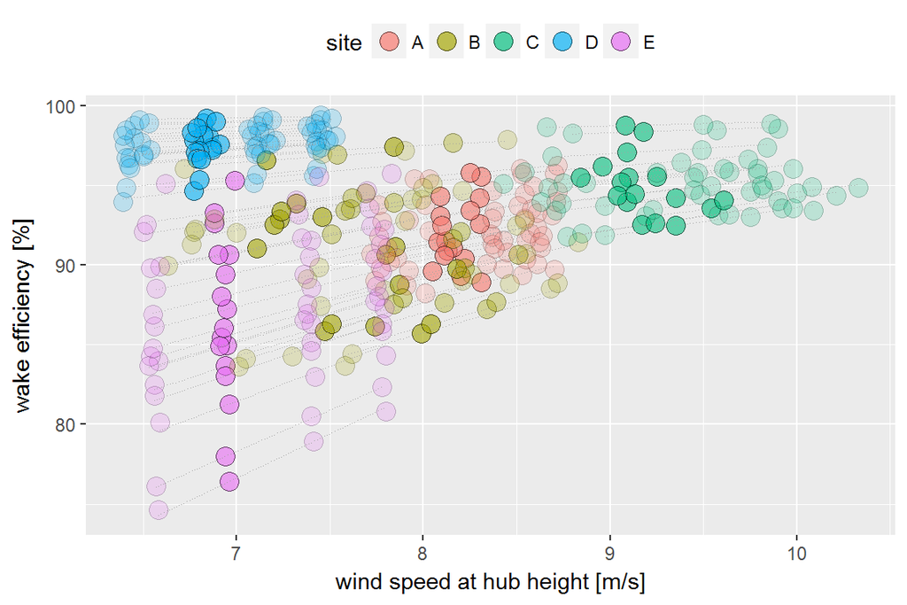

Plot 1.4 shows the comparison of not using any model (assuming efficiency constant) versus using the above model.

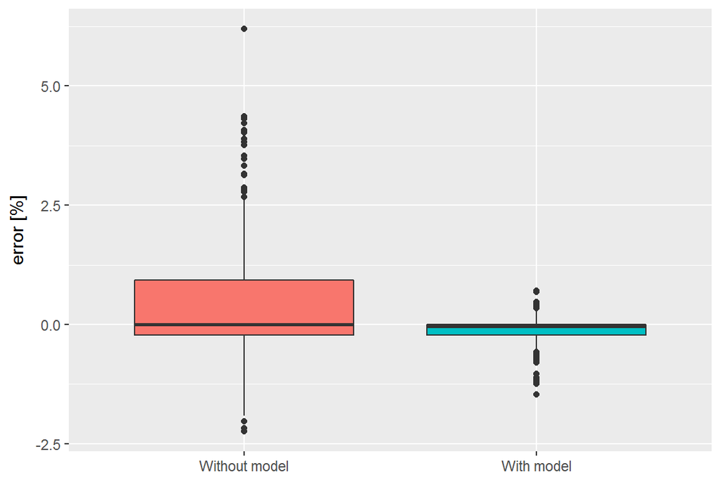

From the graphs above and the annexes (for generator, hub_height and rotor):

- Generator: Clear (good correlation factor) but relatively small impact on efficiency.
- Rotor: No clear impact on the efficiency
- Hub_height: Clear and relatively important impact on efficiency.
- Wind speed: Clear and relatively important impact on efficiency.

It should be noted that wind speed and hub height are highly correlated. A change on the hub height will inevitably have an impact on the wind distribution. The core reason for the efficiency change is the wind speed change, whether this is due to a change in the input wind data or caused by a change in the hub height. For the final model, we will choose to use a correction for wind speed and generator.

### model_1 equation:

$$Eff_2 = A_x * (100 - Eff_1) * (X_2 - X_1) + Eff_1$$

$Eff_1$: reference efficiency [%]  
$Eff_2$: target efficiency [%] (new configuration)  
$X_1$: reference value of the considered parameter (rotor, generator [kW], wind speed [m/s] or hub_height)  
$X_2$: target value of the considered parameter (rotor, generator [kW], wind speed [m/s] or hub_height)  
$A_x$: slope from the model (take a specific value for each parameter x). According to the previous results, we have:

- For generator $A_g$: -8.842e-05 [1/kW]
- For wind speed $A_w$: 0.236 [s/m]

# Benchmark

We will now benchmark the model on a new site with very different configurations (no common parameters). Competitor turbines have also been included. The reference configuration is V126-3.45 at 120m.

```
##          manufacturer   efficiency    rotor    generator   hub_height
##  GE WIND ENERGY: 41   Min.   :79.61   105:41   3000:82   80     :41
##  NORDEX        : 41   1st Qu.:84.71   117:41   3200:41   100    :41
##  SENVION       : 41   Median :87.13   122:41   3300:41   110    :41
##  Siemens       : 41   Mean   :87.82   126:41   3430:41   119    :41
##  Vestas        :164   3rd Qu.:90.94   130:82   3450:41   120    :41
##                       Max.   :98.80   131:41   3600:82   134    :41
##                                       136:41             (Other):82
##    wind_speed
##  Min.   :6.030
##  1st Qu.:6.968
##  Median :7.315
##  Mean   :7.249
##  3rd Qu.:7.610
##  Max.   :8.040
##
```

As previous, we will compare the relative error in efficiency, with & without model.

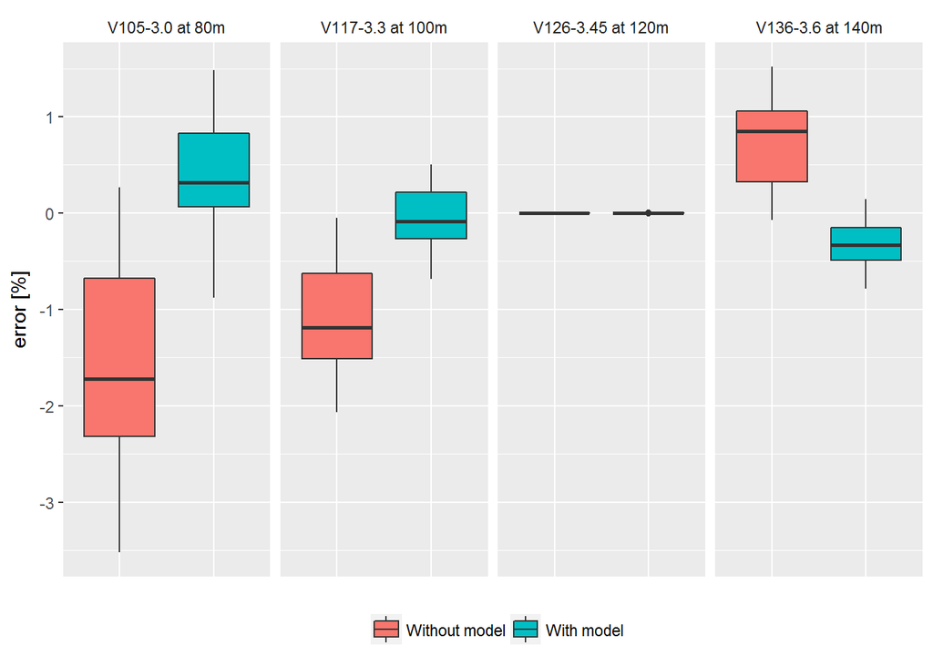

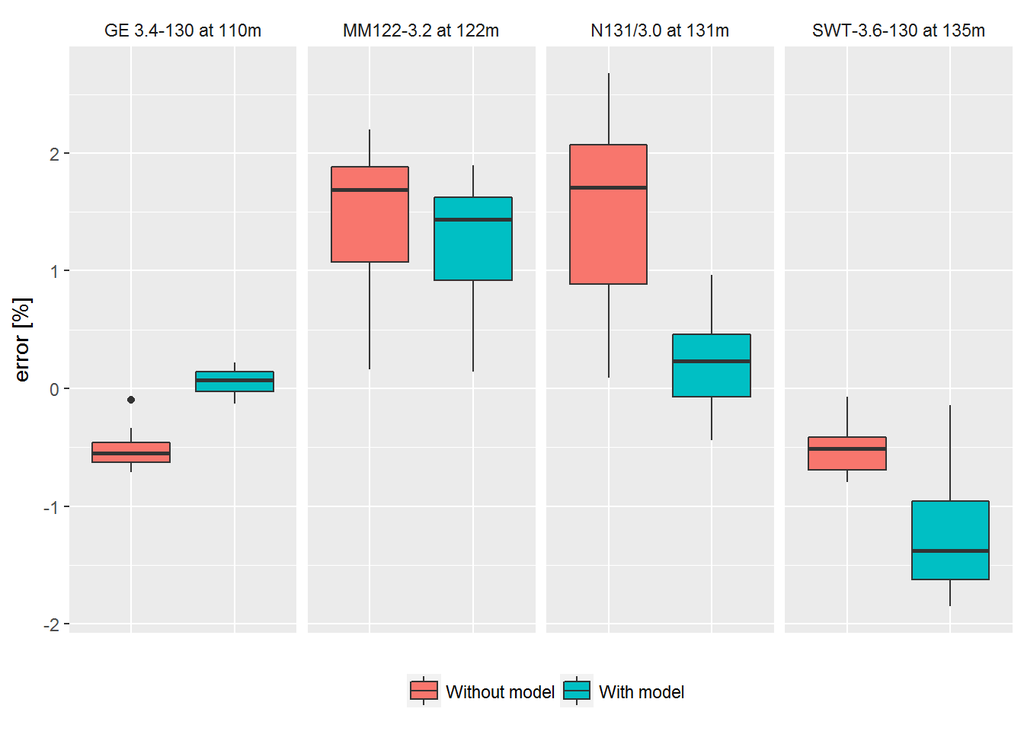

# Annexes

### Plots 2: Generators

Plot 2.1 shows the variation of efficiency along generator size. For each pad a fitted line is plotted.

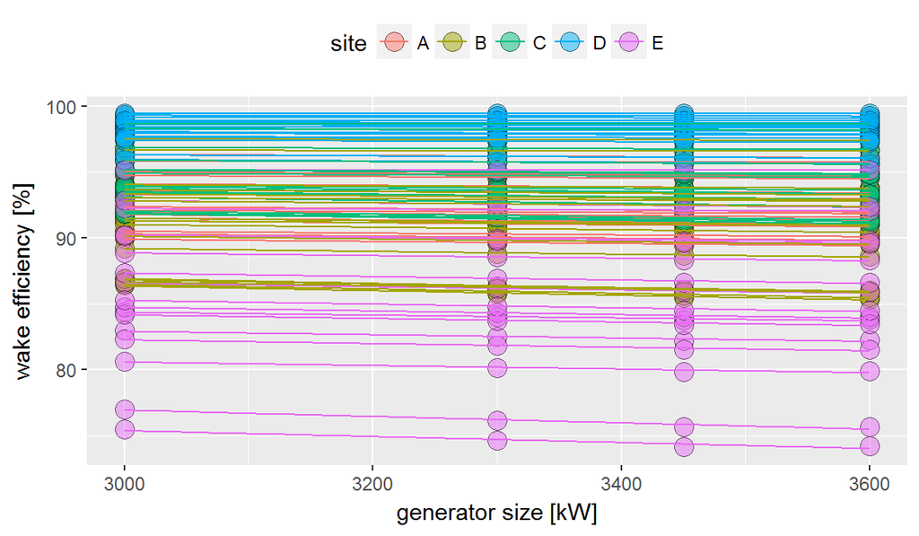

Plot 2.2 shows the variation of the fitted line slopes along efficiency. Again, we will fit a line that would be used for our model.

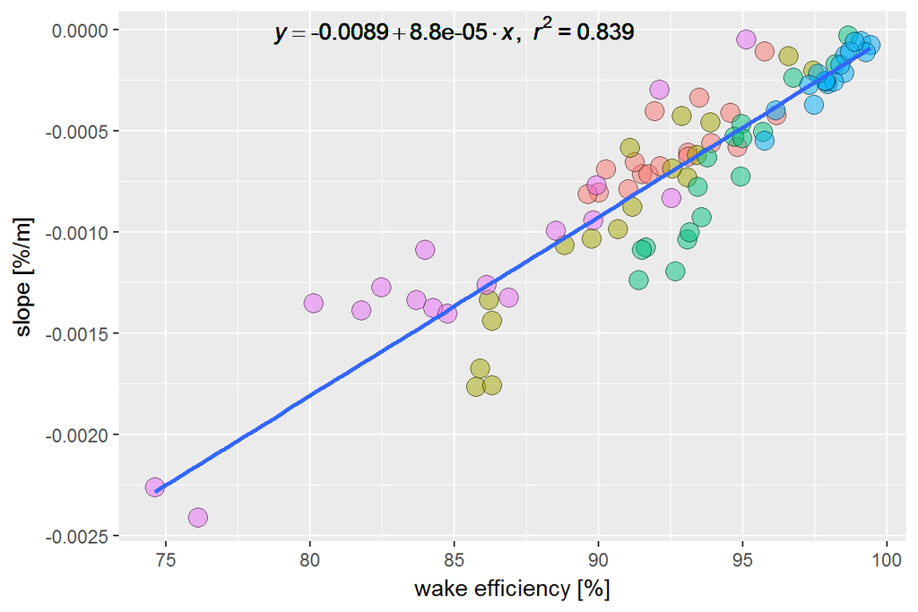

Plot 2.3 shows the results of the model (dashed lines) using a reference point for each pad.

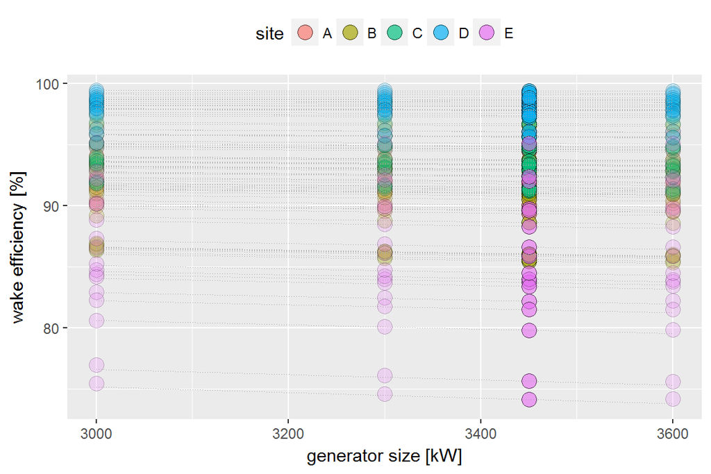

Plot 2.4 shows the comparison of not using any model (assuming efficiency constant) versus using the above model.

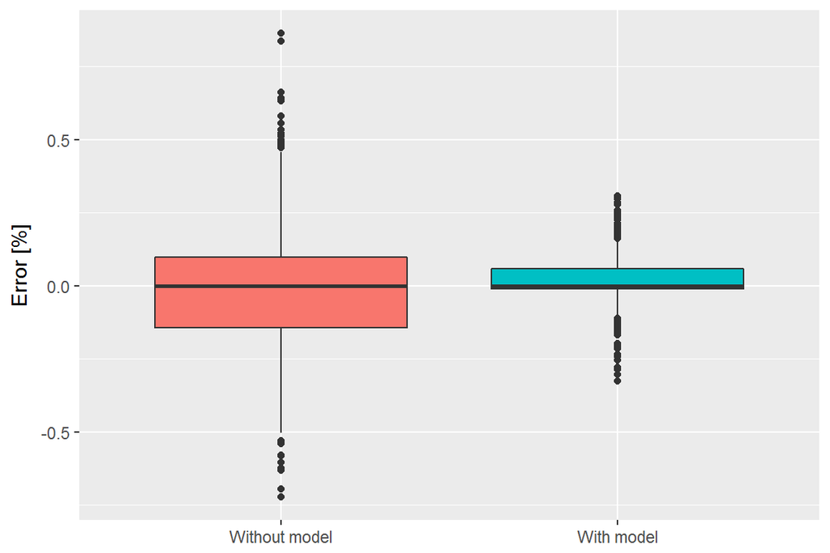

### Plots 3: rotor size

Plot 3.1 shows the variation of efficiency along the rotor size. For each pad a fitted line is plotted.

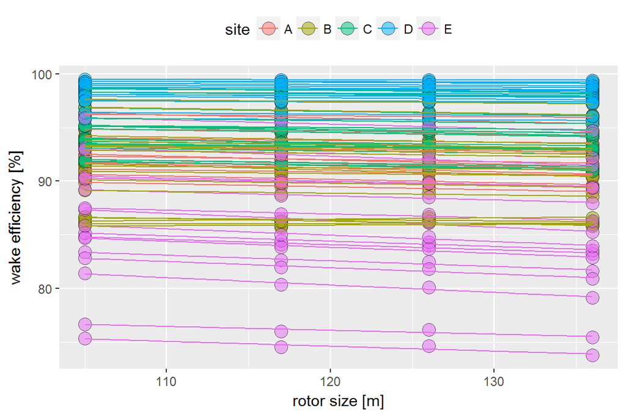

Plot 3.2 shows the variation of the fitted line slopes along efficiency. Again, we will fit a line that would be used for our model.

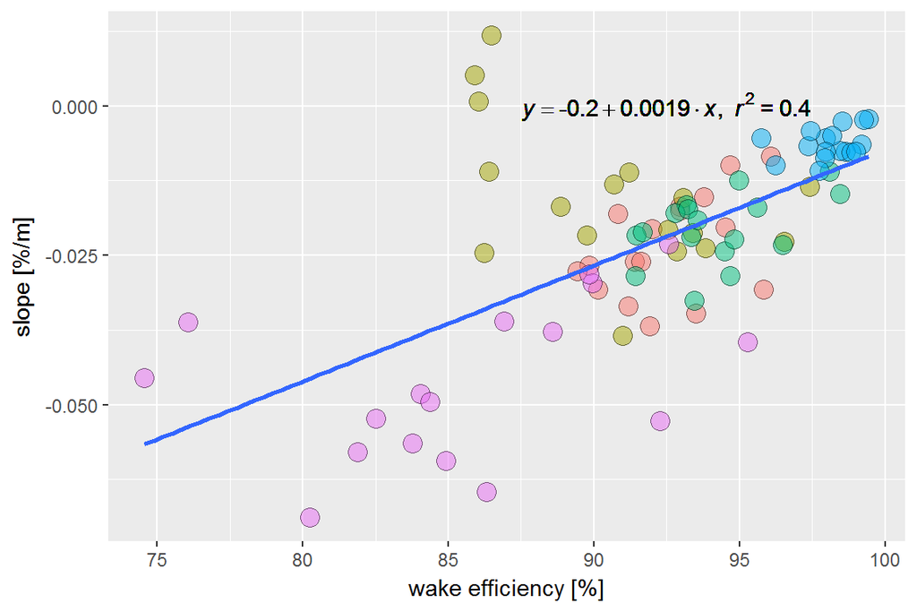

Plot 3.3 shows the results of the model (dashed lines) using a reference point for each pad.

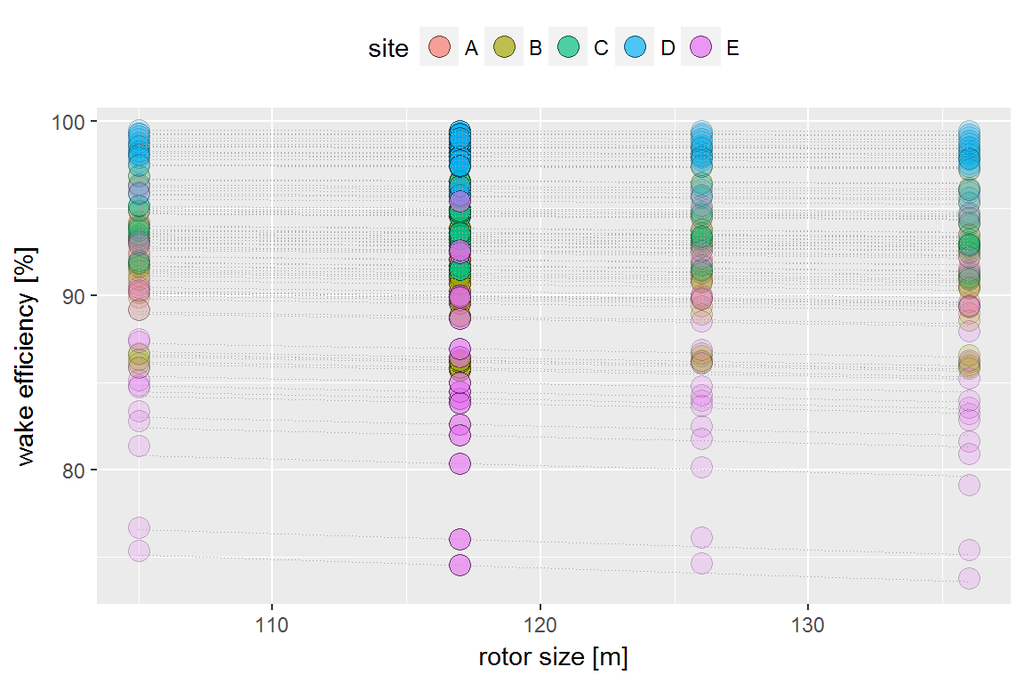

Plot 3.4 shows the comparison of not using any model (assuming efficiency constant) versus using the above model.

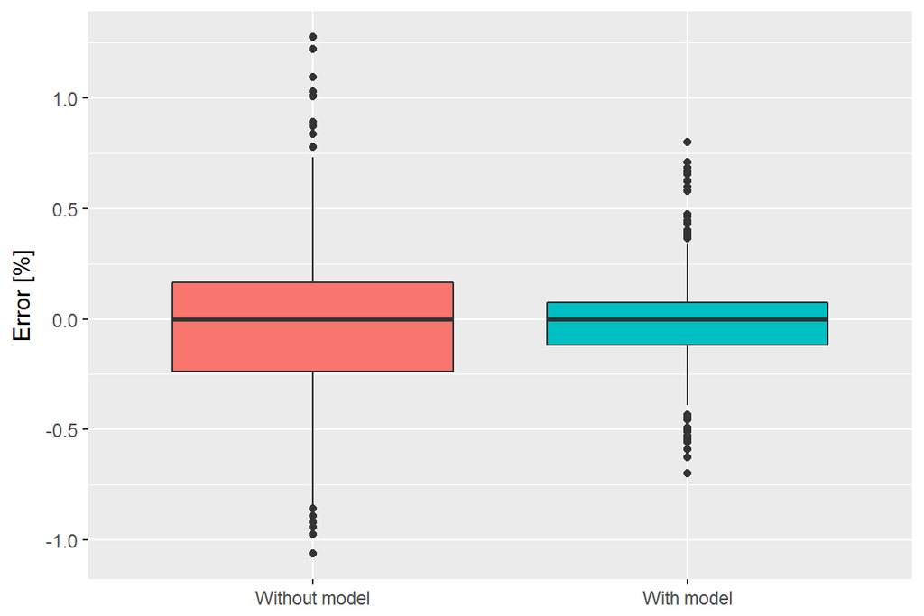

### Plots 4: hub-height

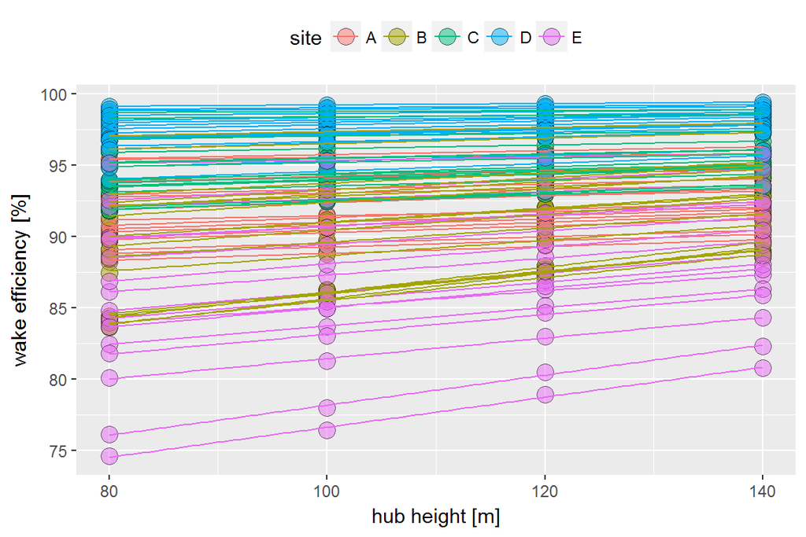

Plot 4.2 shows the variation of the fitted line slopes along efficiency. Again, we will fit a line that would be used for our model.

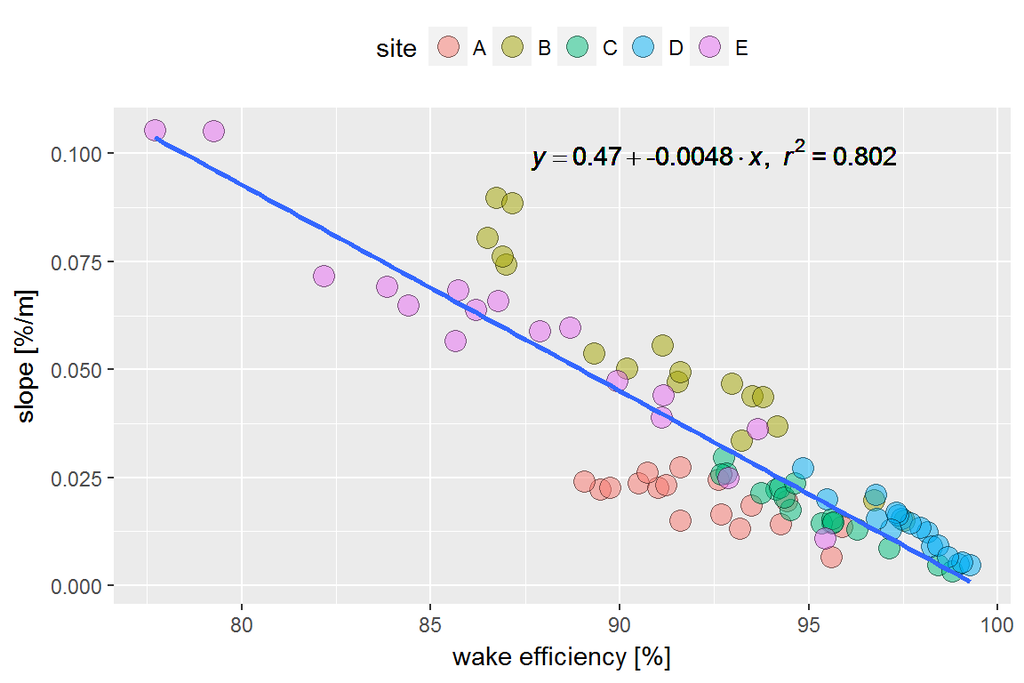

Plot 4.3 shows the results of the model (dashed lines) using a reference point for each pad.

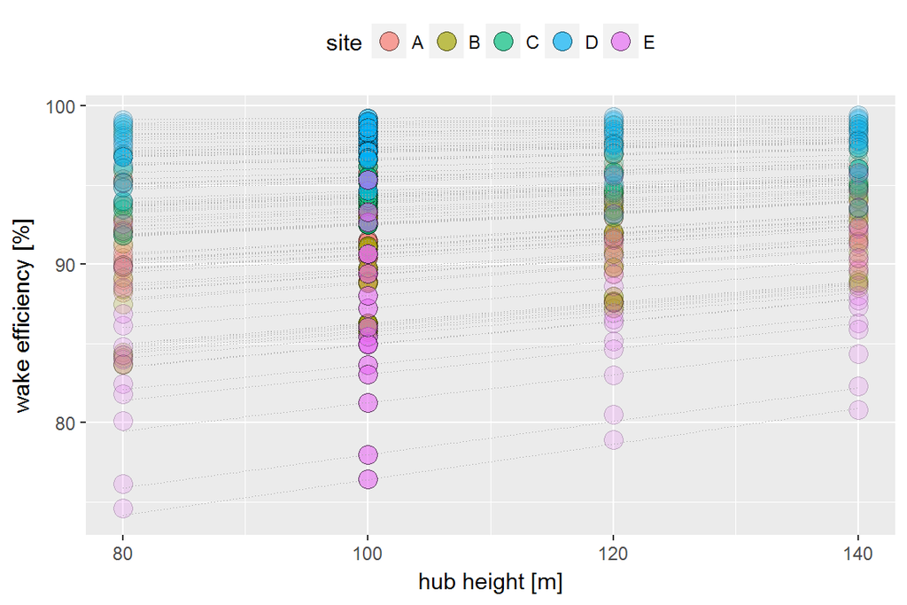

Plot 4.4 shows the comparison of not using any model (assuming efficiency constant) versus using the above model.

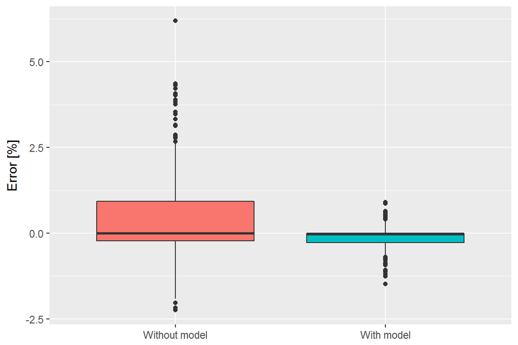